# Title: Rainfall Trends Following the Impact of Hurricane Helene in Sugar Grove, Asheville, and Pigeon River

Sam Tolbert, Chrissie Pantoja, Ana Andino, Gretchen Barbera

2024-12-12

**Project Repository**

https://github.com/chrissiepantoja/TolbertAndinoPantojaBarbera_ENV872_EDA_FinalProject

### 0.1 List of Tables

*Dataset Information*

- Table 1: Data Description

*Seven-Day Time Series Analysis: Trend Patterns*

### 0.2 List of Figures

*Time Series Analysis: Daily and Historical Trend Patterns*

*Seven-Day Time Series Analysis: Trend Patterns*

- Figure 7: Decomposition of 7-Day Moving Average of Daily Discharge for Sugar Grove
- Figure 8: Decomposition of 7-Day Moving Average of Daily Discharge for Asheville
- Figure 9: Decomposition of 7-Day Moving Average of Daily Discharge for Pigeon River

## 1 Context and Motivation

Hurricane Helene struck North Carolina in late September, rapidly intensifying to a Category 4 storm with sustained winds of 140 mph. The hurricane brought catastrophic rainfall, widespread flooding, landslides, destructive winds, and tornados, causing severe disruptions to both the economy and daily life. Months later, the state is still recovering from the storm’s far-reaching effects. Particularly striking is that Helene followed closely on the heels of Hurricane Milton, a Category 5 storm that had already devastated the west coast of the United States. These concurrent events underscore the increasing severity and frequency of hurricanes, highlighting the urgent need to better understand the mechanisms behind and the impacts of such extreme weather events.

The devastation caused by Hurricane Helene has left a profound and lasting impact on North Carolina. The storm wreaked unprecedented destruction, leaving thousands of homes either destroyed or severely damaged. Millions of residents were cut off from critical infrastructure, including water, electricity, telecommunications, and healthcare services (OSBM, 2024). Key infrastructure, such as roadways and bridges, was also heavily damaged. Economically, the storm’s effects will be felt for years to come. Preliminary estimates of the damage and recovery needs across the state total approximately $53.6 billion, which includes $41.1 billion in direct damages, $7.6 billion in indirect impacts, and $4.8 billion needed for strengthening and mitigation efforts (OSBM, 2024). These figures highlight the enormity of the storm’s impact compared to other recent hurricanes, such as Hurricane Florence in 2018, which resulted in $16.7 billion in damages. Beyond the immediate economic losses, the storm significantly altered the state’s physical landscape, eroding valuable topsoil, changing river courses, and submerging homes that had stood for generations. The long-term effects on agriculture and other industries will continue to be felt for years to come (OSBM, 2024).

Why should we understand rainfall trends and why is disaster preparedness important?

The rainfall from Hurricane Helene was both unprecedented and catastrophic. In some areas of North Carolina, over 26 inches of rain fell within a 24-hour period, resulting in widespread flooding that devastated entire towns across 27 counties (OSBM, 2024). Analyzing precipitation patterns and discharge before, during, and after the hurricane is crucial for understanding its long-term effects on regional climates and water systems. This information is vital for informed decision-making in disaster preparedness and water resource management.

Hurricane Helene serves as a reminder for strengthening communities against flooding and extreme weather events. Climate change knows no boundaries, and we should not be surprised when such extreme events continue to occur. By focusing on Helene and its unprecedented nature, this study provides important benchmarks, analyses, and comparisons that will be invaluable for future disaster response planning.

Through examining these rainfall trends, this study aims to emphasize the historical significance of Hurricane Helene as a rare event with far-reaching consequences. Understanding these patterns offers a foundation for contextualizing the storm’s impact within the broader context of climate change, while also identifying anomalies in long-term climatic trends.

## 2 Research Questions

*Question 1: What were the temporal and spatial rainfall patterns in Asheville, Sugar Grove, and Pigeon River following Hurricane Helene?*

*Question 2: How these three counties experience rainfall and flooding impacts differently?*

*Question 3: How have these three counties historically experienced rainfall and flooding impacts?*

## 3 Data Description

To analyze the impact and severity of Hurricane Helene, we utilized data from the United States Geological Survey (USGS). This data is invaluable for understanding extreme weather events due to its accuracy and daily collection. USGS stream gages, which measure daily discharge volumes in cubic feet per second, were chosen for their reliability.

Our analysis focused on daily precipitation trends, flood data, and hurricane patterns. To capture the diverse geographical and hydrological impacts of Helene across North Carolina, we selected three focal sites: Sugar Grove, Asheville, and Pigeon River. These locations were strategically chosen based on their proximity to Helene’s storm path, providing a comprehensive representation of the storm’s effects throughout Western North Carolina.

The study examined three critical parameters: precipitation, stream discharge, and gage height. For each parameter, we calculated daily means and cumulative sums to identify patterns and assess the storm’s severity across different regions.

**Sugar Grove**: Selected for its agricultural setting and the significant impact it experienced from Hurricane Helene.

**Asheville**: Chosen due to its size and role as a metropolitan hub in rural Western North Carolina.

**Pigeon River**: Included because of its proximity to the Tennessee border, highlighting the need for cross-border storm management strategies.

Together, these datasets and locations provide a multi-dimensional view of Hurricane Helene’s impact. This approach bridges historical context, storm-specific data, and hydrological consequences, ensuring that the study not only quantifies the immediate effects of the hurricane but also contributes to long-term disaster preparedness and climate resilience.

USGS stream gage data includes the latitude and longitude of the gage, discharge in cubic feet per second, and the date and time of data recording.

Table 1: Dataset Structure for Analyzing Hurricane Helene’s Impact

[output not shown]

## 4 Data Wrangling

To set up the analysis for the selected sites, retrieve data from the USGS using the “dataRetrieval” package. Begin by loading the necessary libraries, including dataRetrieval, dplyr, and tidyr and other relevant packages for analysis. We defined the site numbers and parameters of interest. The site numbers are: Sugar Grove (03479000), French Broad River in Asheville (03451500), and Pigeon River near Canton (03456500). We focused on the parameters stream discharge (00060), precipitation (00045), and gage height (00065). The statistical codes used are daily mean (00003) for discharge and gage height, and sum (00006) for precipitation.

Create a data retrieval function to streamline the process. This function should utilize readNWISdata from the dataRetrieval package to fetch data for the specified sites, parameters, and stat codes. The function should then clean the data by removing unnecessary “cd” columns, which indicate whether the data is official or provisional, as these columns do not significantly affect the analysis. Rename the remaining columns to include the parameter and statistical codes, ensuring clarity and consistency across datasets.

We applied the function to retrieve and clean data for each site: Sugar Grove, French Broad River, and Pigeon River. This step ensures uniformity in the data preparation process. After cleaning, we combined the datasets into a single, cohesive dataset, confirming that all columns are consistently labeled. This unified dataset allows for effective cross-site comparisons.

Retrieving Data

Retrieving data for Sugar Grove Gage from USGS using USGS’s “dataRetrieval” package. We found its siteNumber is 03479000 from “https://waterdata.usgs.gov/monitoring-location/03479000/#parameterCode=00060&period=P7D&showMedian=false”.

Retrieving data for Asheville Gage from USGS using USGS’s “dataRetrieval” package. We found its siteNumber is 03451500 from “https://waterdata.usgs.gov/monitoring-location/03451500/#parameterCode=00060&period=P7D&showMedian=false”.

Retrieving data for Pigeon River Gage from USGS using USGS’s “dataRetrieval” package. We found its siteNumber is 03456500 from “https://waterdata.usgs.gov/monitoring-location/03456500/#parameterCode=00060&period=P7D&showMedian=false”.

## 5 Daily Time Series Analysis: Daily and Historical Trend Patterns

How unusual was Helene?

First let’s create separate layers from our data for 2024 and then Helene as an event within 2024 a 7 day span from 9/22/24 to 9/29/24.

*Investigating Helene: Let’s see how the week of Helene compares to the rest of 2024 within our parameters*

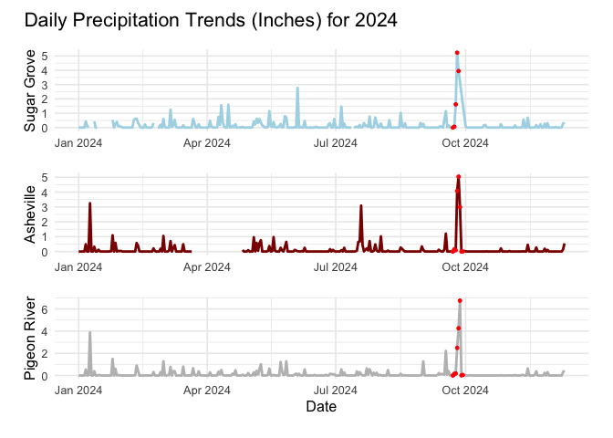

Figure 1: Daily Precipitation Trends (Inches) for 2024

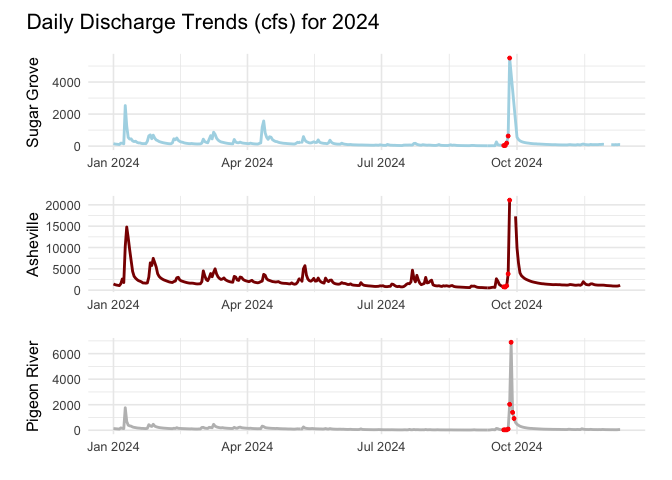

Figure 2: Daily Discharge Trends (cfs) for 2024

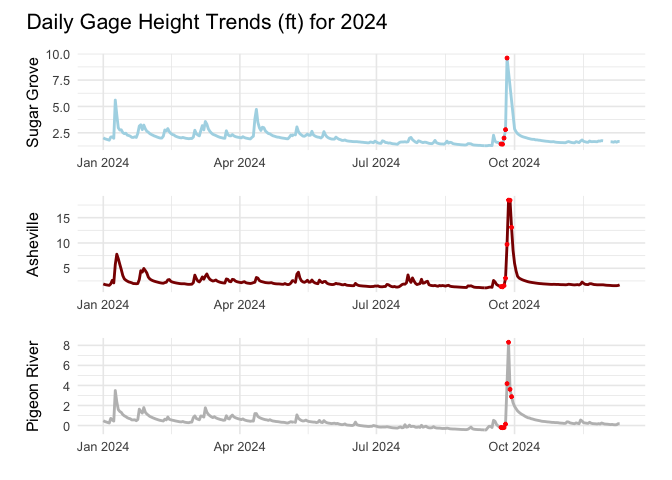

Clearly, Helene was the most significant event for these parameters in 2024.

How do these maximums compare to all historical data we have access to?

Let’s now zoom out to compare these dates with all historical data. This will help us understand how the 2024 data stands in the context of past events.

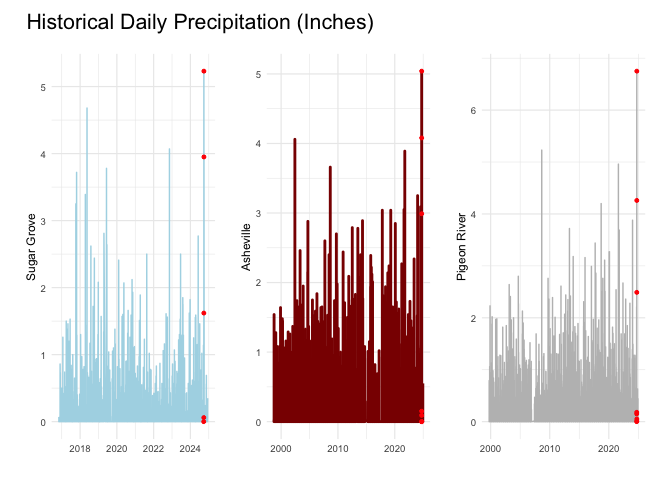

Figure 4: Historical Daily Precipitation (Inches)

This plot illustrates the historical trend of daily precipitation (in inches) across Sugar Grove, Asheville, and Pigeon River. The highest peak, observed during Hurricane Helene, highlights the significant impact of this climate event on these counties.

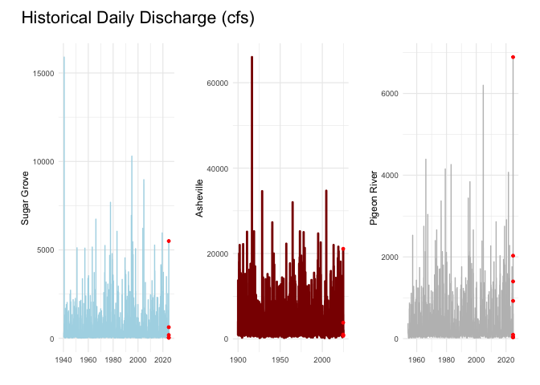

Figure 5: Historical Daily Discharge (cfs)

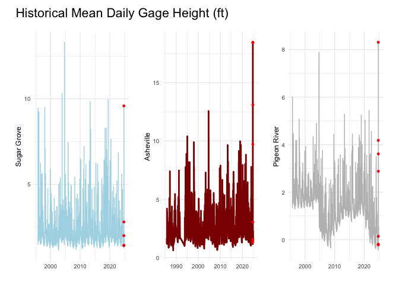

Figure 6: Historical Mean Daily Gage Height (ft)

The plot visualizes the historical mean daily gage height for three locations: Sugar Grove, Asheville, and Pigeon River. Asheville exhibits the most significant fluctuations, with peaks exceeding 15 feet, while Sugar Grove shows a more stable pattern. Pigeon River generally has lower gage heights and less pronounced peaks. Both Asheville and Pigeon River recorded their highest gage heights during Hurricane Helene.

*These graphs reaveal that Helene was responsible for some outlier behavior, but it doesn’t account for seasonality and other trends*

## 6 Seven-Day Time Series Analysis: Seasonality Patterns

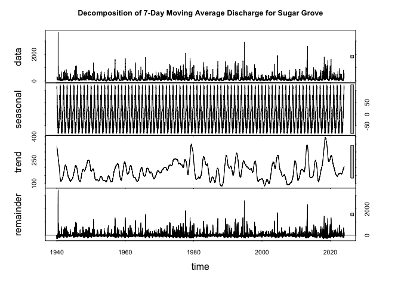

Figure 7: Decomposition of 7-Day Moving Average of Daily Discharge for Sugar Grove

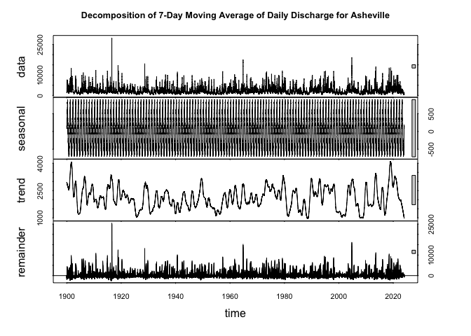

Figure 8: Decomposition of 7-Day Moving Average of Daily Discharge for Asheville

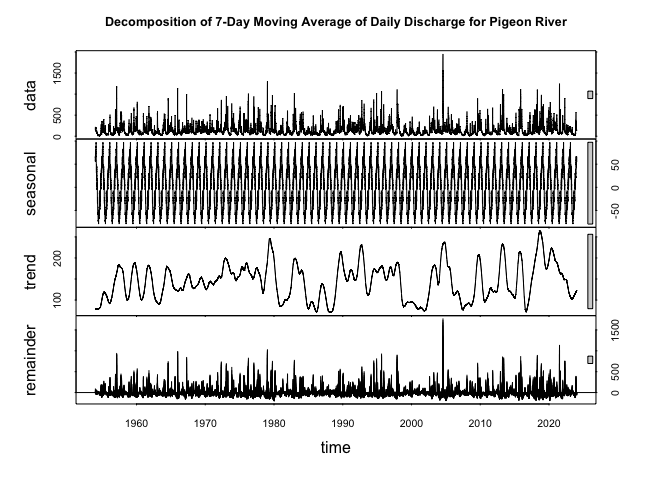

Figure 9: Decomposition of 7-Day Moving Average of Daily Discharge for Pigeon River

To achieve this, we will use the Hazen Method to calculate the recurrence intervals for Hurricane Helene within the analyzed parameters. This method will help contextualize the storm’s magnitude and frequency relative to historical data.

Our first step will be calculating recurrence intervals for 7-day precipitation events. Based on initial analysis, it is reasonable to begin by assuming that Hurricane Helene represents the 7-day averaged maximum for 2024.

Helene Recurrence Intervals: Hazen Analysis

Table 2: Sugar Grove Precipitation Hazen Values for 2024

| Year | Max Event | Rank | Fa Value | Hazen Value |
| --- | --- | --- | --- | --- |
| 2024 | 1.56 | 1 | 5.56 | 18 |

Table 3: Asheville Precipitation Hazen Values for 2024

| Year | Max Event | Rank | Fa Value | Hazen Value |
| --- | --- | --- | --- | --- |
| 2024 | 1.76 | 1 | 1.85 | 54 |

This provides a statistical metric to quantify the observed outliers.

Next, we will calculate the recurrence intervals for 2024 at our last selected site.

Table 4: Pigeon River Precipitation Hazen Values for 2024

| Year | Max Event | Rank | Fa Value | Hazen Value |
| --- | --- | --- | --- | --- |
| 2024 | 1.98 | 1 | 1.92 | 52 |

At Pigeon River, Hurricane Helene was a 52-year event in terms of total precipitation. This indicates that Helene’s precipitation was less unusual at Sugar Grove than it was in Asheville or Pigeon River during the maximum 7-day event. (Hazen interval: 52 years, probability: ~2%)

Let’s now automate this function for all the rest of parameters and run our sites.

Table 5: Sugar Grove Discharge Hazen Values for 2024

| Year | Max Event | Rank | Fa Value | Hazen Value |
| --- | --- | --- | --- | --- |
| 2024 | 1138 | 28 | 32.35 | 3.09 |

The table shows that for Sugar Grove in 2024, the maximum event had a Hazen value of 3.09. This indicates that the event had a return period of approximately 3.09 years, meaning an event of this magnitude or greater is expected to occur, on average, once every 3.09 years. In other words, the event was not particularly unusual or extreme for Sugar Grove.

Table 6: Asheville Discharge Hazen Values for 2024

| Year | Max Event | Rank | Fa Value | Hazen Value |
| --- | --- | --- | --- | --- |
| 2024 | 8778.57 | 52 | 41.2 | 2.43 |

The table shows that for Asheville in 2024, the maximum event had a Hazen value of 2.43. This indicates that the event had a return period of approximately 2.43 years, meaning an event of this magnitude or greater is expected to occur, on average, once every 2.43 years. In other words, the event was not particularly unusual or extreme for Asheville.

Table 7: Pigeon River Discharge Hazen Values for 2024

| Year | Max Event | Rank | Fa Value | Hazen Value |
| --- | --- | --- | --- | --- |
| 2024 | 1815.71 | 2 | 2.11 | 47.33 |

The table shows that for Pigeon River in 2024, the maximum event had a Hazen value of 47.33. This indicates that the event had a return period of approximately 47.33 years, meaning an event of this magnitude or greater is expected to occur, on average, once every 47.33 years. In other words, the event was particularly unusual or extreme for Pigeon River compared to Asheville and Sugar Grove.

Table 8: Sugar Grove Gage Height Hazen Values for 2024

| Year | Max Event | Rank | Fa Value | Hazen Value |
| --- | --- | --- | --- | --- |
| 2024 | 3.54 | 16 | 51.67 | 1.94 |

Table 9: Asheville Gage Height Hazen Values for 2024

| Year | Max Event | Rank | Fa Value | Hazen Value |
| --- | --- | --- | --- | --- |
| 2024 | 11.25 | 1 | 1.28 | 78 |

The table shows that for Asheville in 2024, the maximum event had a Hazen value of 78. This indicates that the event had a return period of approximately 78 years, meaning an event of this magnitude or greater is expected to occur, on average, once every 78 years. In other words, the event was particularly unusual or extreme for Asheville.

Table 10: Pigeon River Gage Height Hazen Values for 2024

| Year | Max Event | Rank | Fa Value | Hazen Value |
| --- | --- | --- | --- | --- |
| 2024 | 3.55 | 2 | 5 | 20 |

The table shows that for Pigeon River in 2024, the maximum event had a Hazen value of 20. This indicates that the event had a return period of approximately 20 years, meaning an event of this magnitude or greater is expected to occur, on average, once every 20 years. In other words, the event was particularly unusual or extreme for Pigeon River

**Map of Gage Sites**

To visually illustrate how unusual Hurricane Helene was at each site, we will create a map that represents the magnitude of the Hazen interval.

The size of the dot on the map will correspond to the rarity of the event: the larger the dot, the less likely the event was to occur.This visualization will help convey the statistical significance of Helene’s impact across the selected sites.

[interactive chart not shown]

Figure 10: Hazen Value (Size)

What we found was very interesting!

Now that we have an easy function, we will download more sites in Western North Carolina that have precipitation, discharge, and gage height available. This will be a helpful visual in understanding the specific impacts in Sugar Grove, Asheville,and Pigeon River compared to the rest of the state.

After selecting the additional sites, they were incorporated into an array to enhance the map.

The map now displays the magnitude of each Hazen interval, representing how unusual the 7-day Hurricane Helene event was at each site. The size of the dot corresponds to the rarity of the event: larger dots indicate more unusual 7-day averages for the given parameter. Although the number of sites with all three parameters is limited, further analysis could enable the creation of increasingly granular data for each site, improving the resolution of our insights.

[interactive chart not shown]

**Why this analysis matters**

This map serves as a representation of relative intensity compared to historical norms. While the size of the dots does not directly indicate the absolute intensity of precipitation or flooding, it reflects the magnitude of these parameters relative to each area’s historical averages.

Flood management infrastructure is typically designed to handle storms with a return period of 50 or 75 years. Therefore, understanding the relative magnitude compared to historical norms is crucial for assessing how well the infrastructure performed under the conditions of Hurricane Helene—or how severely it was overwhelmed.

Although the number of sites with all three parameters is limited, the analysis reveals that Helene’s relative intensity to historical norms was greatest along a path through central Western North Carolina, particularly over Asheville. Based on this, we can reasonably infer that Asheville’s infrastructure faced greater inundation compared to areas in northeastern North Carolina or other sites included in this study.

## 7 Summary and Conclusions

To further contextualize the significance of Helene, we applied the Hazen Method to calculate recurrence intervals, revealing that the storm was a statistical outlier in terms of precipitation for Pigeon River and Asheville, but more typical in Sugar Grove. The Hazen values highlighted the extreme nature of Helene’s impact, particularly in Asheville, where the maximum precipitation event in 2024 was a 54-year occurrence. A visual map of Hazen values reinforced these findings, showing that the storm’s relative intensity was greatest in central Western North Carolina, especially Asheville, suggesting that the region’s infrastructure likely faced more significant challenges in managing the storm’s impacts compared to other areas in the study. This analysis provides valuable insights into the magnitude of the event and its implications for flood management and infrastructure in the region.

## 8 References

North Carolina Office of State Budget and Management (OSBM, 2024). Hurricane Helene DNA.” https://www.osbm.nc.gov/hurricane-helene-dna/open (accessed December 09,2024)

Please Note: Portions of code created in cooperation with “R Wizard” AI on OpenAI’s ChatGPT platform. Limited prompts available upon request.